# supplement 5

Steve Simon

May 27, 2018

This file creates various formulas and graphs needed to illustrate the underlying theory behind the data analyses in survival-lecture-5.Rmd. I am sharing this for those who are curious, but you are not responsible for learning or using the code shown in this supplement.

This file does not need any special libraries other than the ones listed below. Many of the data sets in this program use data from Hosmer, Lemeshow, and May. I made one minor change, however, which was to force all the variable names to lower case.

```r
library(broom)
library(dplyr)
```

```r
library(ggplot2)
library(magrittr)
library(survival)
library(tidyr)
```

## Exponential model

The exponential model is the simplest parametric model. The probability density function for the “standard” exponential distribution is

$f(t)=e^{-t}$

and the survival curve is

$S(t)=e^{-t}$.

The plot of the survival curve is

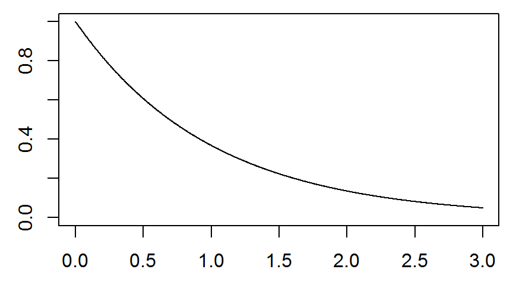

```r
par(mar=c(2.6, 2.6, 0.6, 0.6))
t <- seq(0, 3, length=1000)
plot(t, exp(-t), type="l", ylim=c(0,1))
```

You can include a rate parameter, $\lambda$, to create a density,

$f(t; \lambda)=\lambda e^{-\lambda t}$

and the survival curve is

$S(t; \lambda)=e^{-\lambda t}$

There is an equivalent form using a scale parameter, $\theta$,

$f(t; \theta) = \frac{1}{\theta} e^{-t/\theta}$.

$S(t; \theta) = e^{-t/\theta}$

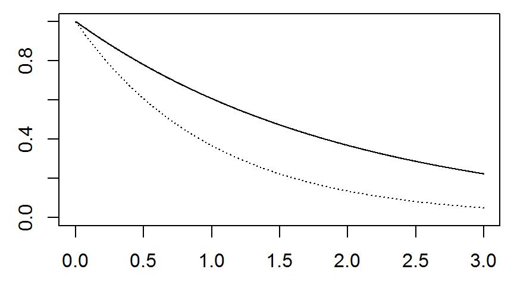

```r
par(mar=c(2.6, 2.6, 0.6, 0.6))
theta <- 2
plot(t, exp(-t/theta), type="l", ylim=c(0,1))
lines(t, exp(-t), lty="dotted")
```

If theta is larger than 1, the effect is to stretch out the exponential and slow down time.

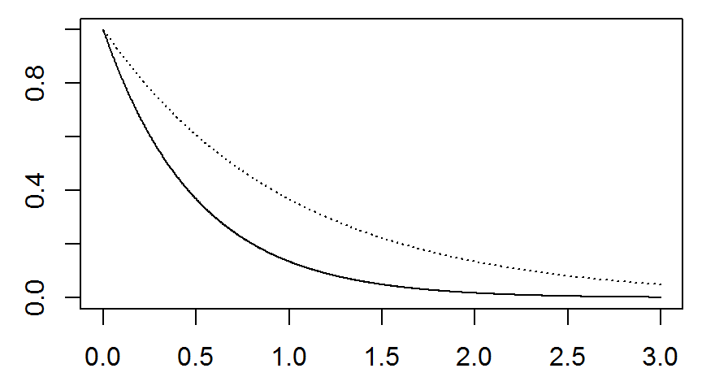

```r
par(mar=c(2.6, 2.6, 0.6, 0.6))
theta <- 0.5
plot(t, exp(-t/theta), type="l", ylim=c(0,1))
lines(t, exp(-t), lty="dotted")
```

The accelerated time model replaces $\theta$ with

$e^{(\beta_0+\beta_1 X)}$

This produces the survival curve

$S(t, X, \beta_0, \beta_1)=e^{-t/e^{(\beta_0+\beta_1 X)}}$

The values of $\beta_0$ and $\beta_1$ will end up stretching or shrinking the time scale.

The pth percentile of the accelerated time model is

$-ln(1-p) e^{\beta_0+\beta_1 X}$

and the ratio of two percentiles, one with X=$X_1$ and the other with X=$X_2$ is

$\frac{-ln(1-p) e^{\beta_0+\beta_1 X_1}} {-ln(1-p) e^{\beta_0+\beta_1 X_2}} = e^{\beta_1 (X_1-X_2)}$

If $X_1$ is one unit larger than $X_2$, this reduces to $e^{\beta_1}$.

This may look quite different than the model we used for Kaplan-Meier curves and the Cox proportional hazards model, but it actually is not. The hazard function is

$h(t, x, \beta_0, \beta_1)=e^{-(\beta_0+\beta_1 x)}$.

Notice that the hazard is constant with respect to t. The baseline hazard, the hazard when X=0 is

$h_0(t)=e^{-\beta_0}$

The hazard ratio for a subject with $x=x_1$ compared to a subject with $x=x_2$ is

$e^{-\beta_1 (x_1-x_2)}$

## Likelihood ratio test

Here’s a quick review of the likelihood ratio test, as it applies to the exponential accelerated time model.

First, let’s fit a null model.

```r
fn <- "~/survival-models/bin/whas100.RData"
load(fn)
null_model <- survreg(
  Surv(time_yrs, fstat=="Dead")~1,
  data=whas100,
  dist="exponential")
summary(null_model)
```

```
##
## Call:
## survreg(formula = Surv(time_yrs, fstat == "Dead") ~ 1, data = whas100,
##     dist = "exponential")
##             Value Std. Error    z        p
## (Intercept)  2.09       0.14 14.9 2.35e-50
##
## Scale fixed at 1
##
## Exponential distribution
## Loglik(model)= -157.6   Loglik(intercept only)= -157.6
## Number of Newton-Raphson Iterations: 5
## n= 100
```

```r
mean(whas100$time_yrs)
```

```
## [1] 4.121561
```

```r
table(whas100$fstat)
```

```
##
## Alive  Dead
##    49    51
```

```r
n0 <- sum(whas100$fstat=="Alive")
n1 <- sum(whas100$fstat=="Dead")
tbar <- round(mean(whas100$time_yrs), 3)
b0 <- round(log(tbar*(n0+n1)/n1), 3)
```

How do you arrive at this mathematically. For the null model, the density is

$f(t) = \frac{1}{e^{\beta_0}} e^{-t/e^{\beta_0}}$

and the survival curve is

$S(t)=e^{-t/e^{\beta_0}}$

The likelihood for any parametric regression model is

$L(\beta)=\Pi_i f(t_i)^{c_i} S(t_i)^{1-c_i}$

Note that for deaths, you use the density, but for censored observations, you use the survival function, which can be thought of as the “average” density from time $t_i$ to infinity.

Let $n_0$ reprensent the number of censored observations and $n_1$ the number of deaths. Then

$L(\beta_0) = \Pi_1 \frac{1}{e^{\beta_0}} e^{-t/e^{\beta_0}} \Pi_0 e^{-t/e^{\beta_0}}$

Where $\Pi_1$ represents the product across all deaths and $\Pi_0$ represents the product across all censored observations. This simplifies to

$L(\beta_0) = \frac{1}{e^{n_1 \beta_0}} e^{-(n_0+n_1) \bar{t}/e^{\beta_0}}$

The log likelihood is

$l(\beta_0)= -n_1 \beta_0 - (n_0+n_1) \bar{t} e^{-\beta_0}$

To find the maximum, take the derivative and set it equal to zero.

$\frac{\partial l}{\partial \beta_0} = -n_1 + (n_0+n_1)\bar{t} e^{-\beta_0} = 0$

$(n_0+n_1)\bar{t} e^{-\hat{\beta_0}} = n_1$

$e^{-\hat{\beta_0}} = \frac{n_1}{(n_0+n_1)\bar{t}}$

$e^{\hat{\beta_0}} = \frac{n_0+n_1}{n_1} \bar{t}$

$\hat{\beta_0} = log\left(\frac{n_0+n_1}{n_1} \bar{t}\right)$

Notice that the overall mean is $\bar{t}$ = 4.122 and that there are $n_0$ = 49 censored observations and $n_1$ = 51 deaths. The estimate of $\hat{\beta_0}$ is

log((49+51) / 51 4.122) = 2.09.

The second derivative of the log likelihood is

$\frac{\partial^2 l}{(\partial \beta_0)^2} = -(n_0+n_1)\bar{t} e^{-\beta_0}$

If you compute this negative of this second derivative at the maximum likelihood estimate, $\hat{\beta_0}$, you get the information matrix,

$I(\hat{\beta_0}) = (n_0+n_1)\bar{t} e^{-log\left(\frac{n_0+n_1}{n_1} \bar{t}\right)}$

$= (n_0+n_1)\bar{t} \left(\frac{n_1}{(n_0+n_1)\bar{t}} \right)$

$= n_1$

The standard error of the maximum likelihood estimate is

$\frac{1}{\sqrt{I(\hat{\beta_0})}}$

which is simply

$\frac{1}{\sqrt{n_1}}$

Note that the precision of the estimator is influenced only by deaths and not by censored observations.

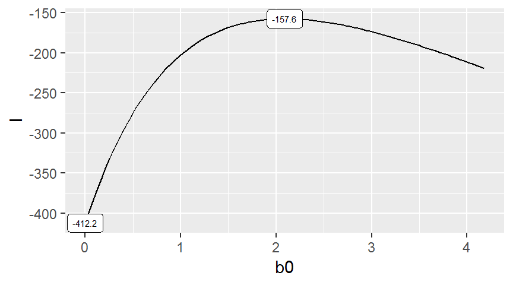

```r
par(mar=c(2.6, 2.6, 0.6, 0.6))
f <- function(t, b) {
  return(-b-t/exp(b))
}
s <- function(t, b) {
  return(-t/exp(b))
}
li <- function(t, c, b0) {
  # male, censored
  if (c!="Dead") {return(s(t, b0))}
  # male, death
  if (c=="Dead")  {return(f(t, b0))}
}
n0 <- 99
b0 <- seq(0, 2*2.09, length=n0)
l <- rep(0, n0)
for (i0 in 1:n0) {
  for (k in 1:100) {
    l[i0] <- l[i0] +
      li(whas100$time_yrs[k], whas100$fstat[k], b0[i0])
  }
}
m <- which.max(l)
data.frame(b0=b0, l=l) %>%
  ggplot(aes(b0, l)) +
  geom_line() +
  geom_label(aes(x=b0[m], y=l[m], label=round(l[m], 1)), size=2) +
  geom_label(aes(x=b0[1], y=l[1], label=round(l[1], 1)), size=2)
```

Now let’s fit a model with gender as an independent variable. The survival curve is

$S(t)=e^{-t/e^{\beta_0}}$

for males and

$S(t)=e^{-t/e^{\beta_0+\beta_1}}$

for females. The density functions for males and females are

$f(t) = \frac{1}{e^{\beta_0}} e^{-t/e^{\beta_0}}$

$f(t) = \frac{1}{e^{\beta_0+\beta_1}} e^{-t/e^{\beta_0+\beta_1}}$

The likelihood for any parametric regression model is

$L(\beta)=\Pi_i f(t_i)^{c_i} S(t_i)^{1-c_i}$

For this particular model, partition the observations into four sets: female censored ($F_0$), female deaths ($F_1$), male censored ($M_0$), and male deaths ($M_1$), with $f_0$, $f_1$, $m_0$, and $m_1$ observations in each group. Then the likelihood becomes

$L(\beta)=\Pi_{F_0} e^{-t_i/e^{\beta_0+\beta_1}} \Pi_{F_1}\frac{1}{e^{\beta_0+\beta_1}} e^{-t_i/e^{\beta_0+\beta_1}} \Pi_{M_0} e^{-t_i/e^{\beta_0}} \Pi_{M_1}\frac{1}{e^{\beta_0}} e^{-t_i/e^{\beta_0}}$

$L(\beta)=\frac{1}{e^{(f_1+m_1)\beta_0+f_1\beta_1}} e^{-\frac{(f_0+f_1)\bar{t}_F}{e^{\beta_0+\beta_1}} -\frac{(m_0+m_1)\bar{t}_M}{e^{\beta_0}}}$

Take the log of both sides to get a log likelihood.

$l(\beta)=-(f_1+m_1)\beta_0-f_1\beta_1 -(f_0+f_1)\bar{t}_F e^{-\beta_0-\beta_1} - (m_0+m_1)\bar{t}_M e^{-\beta_0}$

To find the maximum, take the two partial derivates and set them equal to zero.

$\frac{\partial l}{\partial \beta_0}=-(f_1+m_1) +(f_0+f_1)\bar{t}_F e^{-\beta_0-\beta_1} + (m_0+m_1)\bar{t}_M e^{-\beta_0}=0$

$\frac{\partial l}{\partial \beta_1}=-f_1 + (f_0+f_1)\bar{t}_F e^{-\beta_0-\beta_1}=0$

The solution to these two equations is

$\hat\beta_0=log(\frac{m_0+m_1}{m_1}\bar{t}_M)$

```r
gender_model <- survreg(
  Surv(time_yrs, fstat=="Dead")~gender,
  data=whas100,
  dist="exponential")
summary(gender_model)
```

```
##
## Call:
## survreg(formula = Surv(time_yrs, fstat == "Dead") ~ gender, data = whas100,
##     dist = "exponential")
##               Value Std. Error     z        p
## (Intercept)   2.318      0.189 12.26 1.42e-34
## genderFemale -0.602      0.281 -2.14 3.25e-02
##
## Scale fixed at 1
##
## Exponential distribution
## Loglik(model)= -155.4   Loglik(intercept only)= -157.6
##  Chisq= 4.42 on 1 degrees of freedom, p= 0.036
## Number of Newton-Raphson Iterations: 5
## n= 100
```

```r
tapply(whas100$time_yrs, whas100$gender, mean)
```

```
##     Male   Female
## 4.372769 3.655031
```

```r
table(whas100$gender, whas100$fstat)
```

```
##
##          Alive Dead
##   Male      37   28
##   Female    12   23
```

You can calculate the likelihoods yourself.

$L(\beta)=\Pi_i f(t_i, X_i, \beta)^{c_i} S(t_i, X_i, \beta)^{1-c_i}$

Create a function for the likelihood.

```r
li <- function(t, c, g, b0, b1) {
  # male, censored
  if (c!="Dead" & g!="Female") {return(s(t, b0))}
  # male, death
  if (c=="Dead" & g!="Female")  {return(f(t, b0))}
  # female, censored
  if (c!="Dead" & g=="Female") {return(s(t, b0+b1))}
  # female, death
  if (c=="Dead" & g=="Female")  {return(f(t, b0+b1))}
}
```

Draw likelihood surface

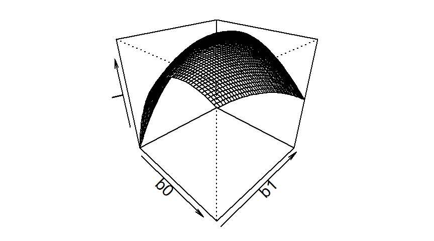

```r
par(mar=c(0.6, 0.6, 0.6, 0.6))
n0 <- 49
n1 <- 49
b0 <- seq(2.318-0.602, 2.318+0.602, length=n0)
b1 <- seq(-2*0.602, 0, length=n1)
l <- matrix(0, n0, n1)
for (i0 in 1:n0) {
  for (i1 in 1:n1) {
    for (k in 1:100) {
      l[i0, i1] <- l[i0, i1] +
            li(whas100$time_yrs[k],
               whas100$fstat[k],
               whas100$gender[k],
               b0[i0], b1[i1])
    }
  }
}
persp(b0, b1, l, theta=45, phi=30)
```

Draw contour plot.

```r
par(mar=c(2.6, 2.6, 0.6, 0.6))
b0 <- seq(0, 2.318+0.602, length=n0)
b1 <- seq(-2*0.602, 0, length=n1)
l <- matrix(0, n0, n1)
for (i0 in 1:n0) {
  for (i1 in 1:n1) {
    for (k in 1:100) {
      l[i0, i1] <- l[i0, i1] +
            li(whas100$time_yrs[k],
               whas100$fstat[k],
               whas100$gender[k],
               b0[i0], b1[i1])
    }
  }
}
lv <- -c(156:160, 162, 165, 170, 180, 190, 200, 250, 300, 350, 400, 600, 800)
contour(b0, b1, l, levels=rev(lv))
# abline(h=-0.602, lty="dotted")
# abline(v=2.318, lty="dotted")
m <- b0[which.max(l[ , n1])]
m
```

```
## [1] 2.068333
```

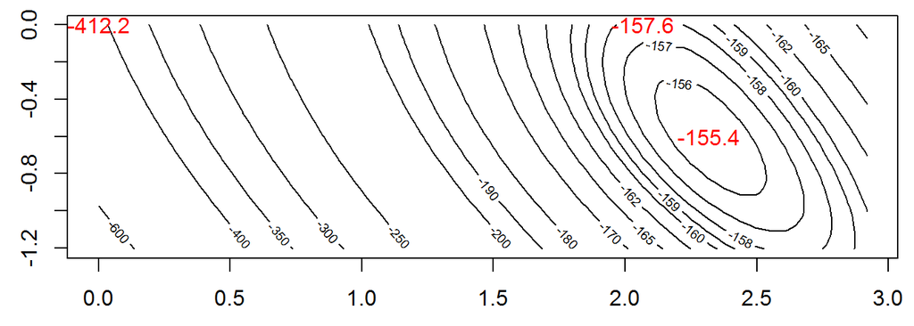

```r
text(2.318, -0.602, round(max(l), 1), col="red")
text(m, 0, round(max(l[ , n1]), 1), col="red")
text(0, 0, round(l[1, n1], 1), col="red")
```

```r
max(l)
```

```
## [1] -155.3602
```

```r
max(l[ , n1])
```

```
## [1] -157.58
```

```r
l[1, n1]
```

```
## [1] -412.1561
```

## Weibull model

The standard Weibull distribution has a density

$f(t, k)=k t^{k-1} e^{-t^k}$

and a survival function

$S(t, k)=e^{-t^k}$.

You can add a scale parameter, $\theta$, to get

$f(t, k, \theta) = \frac {k} {\theta} \left( \frac {t} {\theta} \right)^{k-1} e^{-\left( \frac {t} {\theta} \right)^k}$

and a survival function

$S(t, k, \theta)=e^{-\left(\frac{t}{\theta}\right)^k}$.

The value of k controls whether the Weibull distribution has an increasing hazard (k>1), constant hazard (k=1), or decreasing hazard (k<1).

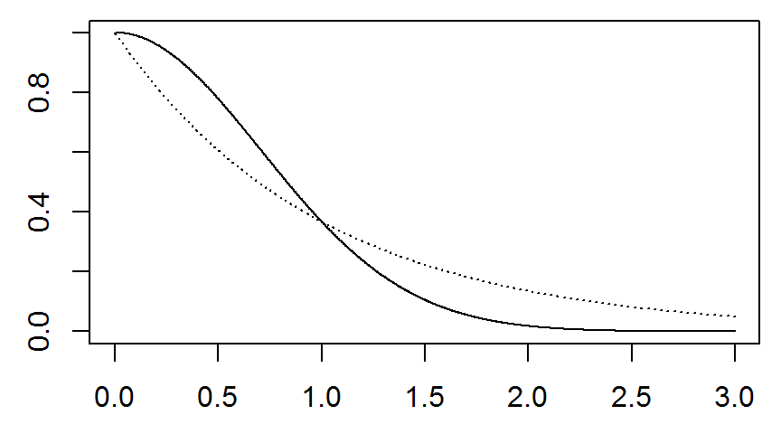

```r
par(mar=c(2.6, 2.6, 0.6, 0.6))
plot(t, 1-pweibull(t, shape=2), type="l", ylim=c(0,1))
lines(t, 1-pweibull(t, shape=1), lty="dotted")
```

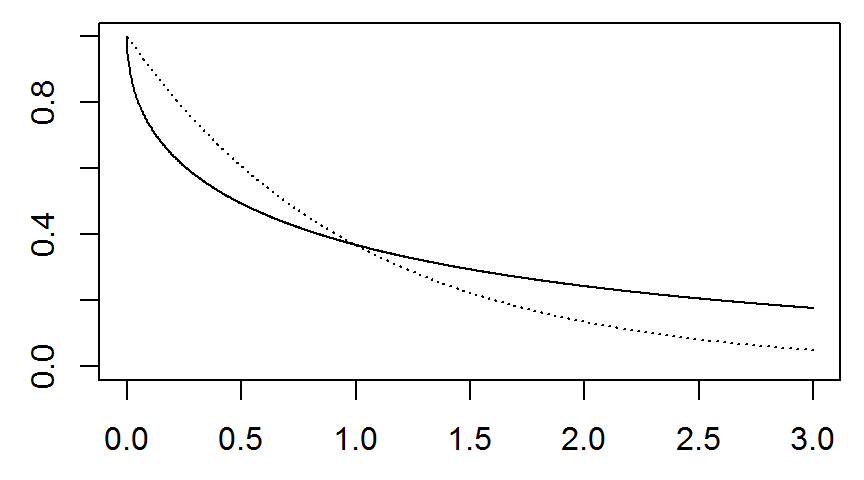

```r
plot(t, 1-pweibull(t, shape=0.5), type="l", ylim=c(0,1))
lines(t, 1-pweibull(t, shape=1), lty="dotted")
```

The scale parameter, $\theta$, will stretch or squeeze the survival curve along the time axis.

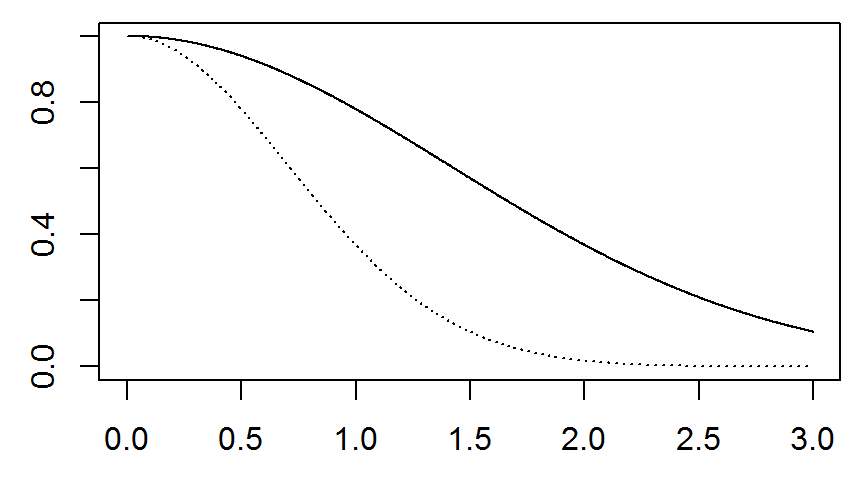

```r
par(mar=c(2.6, 2.6, 0.6, 0.6))
plot(t, 1-pweibull(t, shape=2, scale=2), type="l", ylim=c(0,1))
lines(t, 1-pweibull(t, shape=2, scale=1), lty="dotted")
```

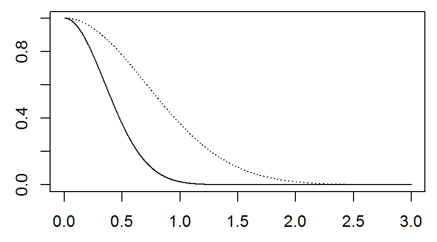

```r
plot(t, 1-pweibull(t, shape=2, scale=0.5), type="l", ylim=c(0,1))
lines(t, 1-pweibull(t, shape=2, scale=1), lty="dotted")
```

You can fit an accelerated time model for the Weibull distribution as well.

$S(t, k, X, \beta_0, \beta_1) = e^{-\left( \frac {t} {e^{\beta_0 + \beta_1 x}} \right)^k}$.

```r
weibull_model <- survreg(
  Surv(time_yrs, fstat=="Dead")~gender,
  data=whas100,
  dist="weibull")

r_response <- residuals(weibull_model, type="response")
r_deviance <- residuals(weibull_model, type="deviance")
r_dfbeta <- residuals(weibull_model, type="dfbeta")
r_dfbetas <- residuals(weibull_model, type="dfbetas")
r_working <- residuals(weibull_model, type="working")
r_ldcase <- residuals(weibull_model, type="ldcase")
r_ldresp <- residuals(weibull_model, type="ldresp")

head(r_response)
```

```
##           1           2           3           4           5           6
## -12.9601327  -4.8628205  -6.3482231  -5.6184673  -9.6774496  -0.2331148
```

```r
head(r_deviance)
```

```
##           1           2           3           4           5           6
## -2.80477222 -1.06420041 -0.45817710 -1.66280936 -0.86595930 -0.02968477
```

```r
head(r_dfbeta)
```

```
##    (Intercept) genderFemale   Log(scale)
## 1  0.002670449  0.011493880  0.052513319
## 2 -0.003313129 -0.040312072 -0.003432221
## 3 -0.036191315  0.031363980 -0.017897028
## 4  0.013827934 -0.062829310  0.014324988
## 5 -0.043676477  0.040071167 -0.013366451
## 6 -0.016005658  0.009802495 -0.016580992
```

```r
head(r_dfbetas)
```

```
##           [,1]        [,2]        [,3]
## 1  0.009389456  0.02936025  0.40882945
## 2 -0.011649157 -0.10297416 -0.02672071
## 3 -0.127250805  0.08011693 -0.13933288
## 4  0.048619833 -0.16049276  0.11152365
## 5 -0.153569076  0.10235879 -0.10406120
## 6 -0.056276838  0.02503974 -0.12908721
```

```r
head(r_working)
```

```
##             1             2             3             4             5
## -185.34171645   -3.57259032   -0.86972639  -11.88989605   -2.36848758
##             6
##   -0.04101387
```

```r
head(r_ldcase)
```

```
##          1          2          3          4          5          6
## 0.20233950 0.02357388 0.02487482 0.04747801 0.02528389 0.01670107
```

```r
head(r_ldresp)
```

```
##          1          2          3          4          5          6
## 0.01727897 0.02063152 0.01435138 0.02080320 0.01387842 0.04126048
```

```r
p_response <- predict(weibull_model, type="response")
p_linear <- predict(weibull_model, type="linear")
p_terms <- predict(weibull_model, type="terms")

head(p_response)
```

```
## [1] 12.976560  5.886777 12.976560  5.886777 12.976560  5.886777
```

```r
head(p_linear)
```

```
## [1] 2.563145 1.772709 2.563145 1.772709 2.563145 1.772709
```

```r
exp(head(p_linear))
```

```
## [1] 12.976560  5.886777 12.976560  5.886777 12.976560  5.886777
```

```r
head(p_terms)
```

```
##       gender
## 1  0.2766526
## 2 -0.5137834
## 3  0.2766526
## 4 -0.5137834
## 5  0.2766526
## 6 -0.5137834
```

```r
term_totals <- apply(p_terms, 1, sum)
head(term_totals)
```

```
##          1          2          3          4          5          6
##  0.2766526 -0.5137834  0.2766526 -0.5137834  0.2766526 -0.5137834
```

The hazard function for the Weibull distribution is

$h(t, k) = k t^{k-1}$

Save everything for possible later re-use.

```r
save.image("~/survival-models/bin/supplement-5.RData")
```